# ANOVA

# 5 Diagnostic EDA (Model Diagnostic)

## 5.1 **Test of Linearity — Not Applicable**

Linearity only exists between a predictor and outcome in a regression model. Group membership has no inherent order or scale, so there is no “relationship” between predictor and outcome whose shape (linear or otherwise) could be tested.

## 5.2 **Test of Independence of Errors (Autocorrelation)**

When observations are collected in a sequence (for example, repeated measurements over time, or runs executed one after another), the assumption of independence may be violated by autocorrelation: a correlation between residuals based on their order or proximity in the sequence. The Durbin-Watson test can be used to detect this. This test is not generally required for ANOVA designs without a natural ordering, since independence in those cases follows from random assignment and study design rather than from a statistical test.

Autocorrelation is consequential because, when positive, it leads to underestimated standard errors and inflated t-statistics, which can make findings appear more significant than they actually are. Negative autocorrelation has the opposite effect: standard errors become overestimated and tests become conservative.

A Durbin-Watson statistic close to 2 suggests no autocorrelation, while values approaching 0 indicate positive autocorrelation and values approaching 4 indicate negative autocorrelation.

For the Durbin-Watson test, as implemented by default in R’s `dwtest()`:

- The null hypothesis, H<sub>0</sub>, is that there is no autocorrelation (ρ = 0).
- The alternative hypothesis, H<sub>a</sub>, is that there is positive autocorrelation (ρ > 0).

By default, `dwtest()` tests only for positive autocorrelation, since this is the form most commonly encountered in sequential data. If a test against negative autocorrelation, or against autocorrelation in either direction, is needed instead, the `alternative` argument can be set to `"less"` or `"two.sided"`, respectively.

If the p-value of the Durbin-Watson statistic is greater than 0.05, there is no evidence to reject the null hypothesis of no autocorrelation.

Example: Algorithm benchmarks run sequentially on the same machine, where thermal throttling, caching, or background load could make consecutive runs correlated.

```r
lmtest::dwtest(one_way_anova_result)
```

```
#>
#>  Durbin-Watson test
#>
#> data:  one_way_anova_result
#> DW = 2.1638, p-value = 0.8292
#> alternative hypothesis: true autocorrelation is greater than 0
```

```r
lmtest::dwtest(two_way_anova_result)
```

```
#>
#>  Durbin-Watson test
#>
#> data:  two_way_anova_result
#> DW = 2.1142, p-value = 0.7862
#> alternative hypothesis: true autocorrelation is greater than 0
```

```r
lmtest::dwtest(manova_result)
```

```
#>
#>  Durbin-Watson test
#>
#> data:  manova_result
#> DW = 2.1559, p-value = 0.8146
#> alternative hypothesis: true autocorrelation is greater than 0
```

**Interpretation:** The Durbin-Watson statistic for one-way ANOVA (DW = 2.1638), two-way ANOVA (DW=2.1142), and multiple analysis of variance (MANOVA) (DW=2.1559) are all close to 2, indicating little evidence of autocorrelation among the residuals. The one-way ANOVA p-value (0.8292), two-way ANOVA p-value (0.7862), and MANOVA p-value (0.8146) are far greater than 0.05, so there is no evidence to reject the null hypothesis. The assumption of independent errors is therefore reasonably supported.

## 5.3 **Test of Normality of the Distribution of the Errors**

The Shapiro–Wilk test assesses whether a sample of data could reasonably have come from a normally distributed population. It enables you to answer the question, “Is this data “normal enough” for methods that assume normality?”

It tests the following hypothesis:

> H₀: The population from which the sample is drawn is normally distributed.  
> H₁: The population from which the sample is drawn is not normally distributed.

The test compares your ordered data values to the values you would expect if the data were perfectly normal. The more they disagree, the lower the Shapiro–Wilk statistic (W), and the smaller the p-value.

It uses the same logic as a Q–Q plot, but expressed mathematically.

**Interpretation**

If p-value > 0.05

You fail to reject the null hypothesis. There is no evidence that the data deviates from a normal distribution. However, this does not mean the data is truly normal. It simply means it is “normal enough” for the chosen statistical test of hypothesis.

**Sample Size Matters**

- Small samples (n < 30): Shapiro–Wilk has low power. It often fails to detect non-normality even when it is present.
- Large samples (n > 50): Shapiro–Wilk gains enough power to detect very small, practically negligible deviations from normality. A significant result at large n does not necessarily mean the deviation matters for your analysis; ANOVA is fairly robust to mild non-normality when samples are large. Pairing the test with a Q-Q plot helps judge whether a detected deviation is practically meaningful.

```r
shapiro.test(residuals(one_way_anova_result))
```

```
#>
#>  Shapiro-Wilk normality test
#>
#> data:  residuals(one_way_anova_result)
#> W = 0.98827, p-value = 0.09886
```

```r
shapiro.test(residuals(two_way_anova_result))
```

```
#>
#>  Shapiro-Wilk normality test
#>
#> data:  residuals(two_way_anova_result)
#> W = 0.99391, p-value = 0.587
```

```r
result <- MVN::mvn(data = residuals(manova_result), mvn_test = "mardia")
print(result$multivariate_normality)
```

```
#>              Test Statistic p.value     Method      MVN
#> 1 Mardia Skewness    10.708   0.381 asymptotic ✓ Normal
#> 2 Mardia Kurtosis     0.277   0.782 asymptotic ✓ Normal
```

The test of normality of the distribution of the errors assesses whether the errors (residuals) are approximately normally distributed, i.e., most errors are close to zero and large errors are rare. A Q-Q plot can be used to conduct the test of normality.

A Q-Q plot is a scatterplot of the quantiles of the errors against the quantiles of a normal distribution. Quantiles are statistical values that divide a dataset or probability distribution into equal-sized intervals. They help in understanding how data is distributed by marking specific points that separate the data into groups of equal size. Examples of quantiles include: quartiles (4 equal parts), percentiles (100 equal parts), deciles (10 equal parts), etc.

If the points in the Q-Q plot fall along a straight line, then the normality assumption is satisfied. If the points in the Q-Q plot do not fall along a straight line, then the normality assumption is not satisfied.

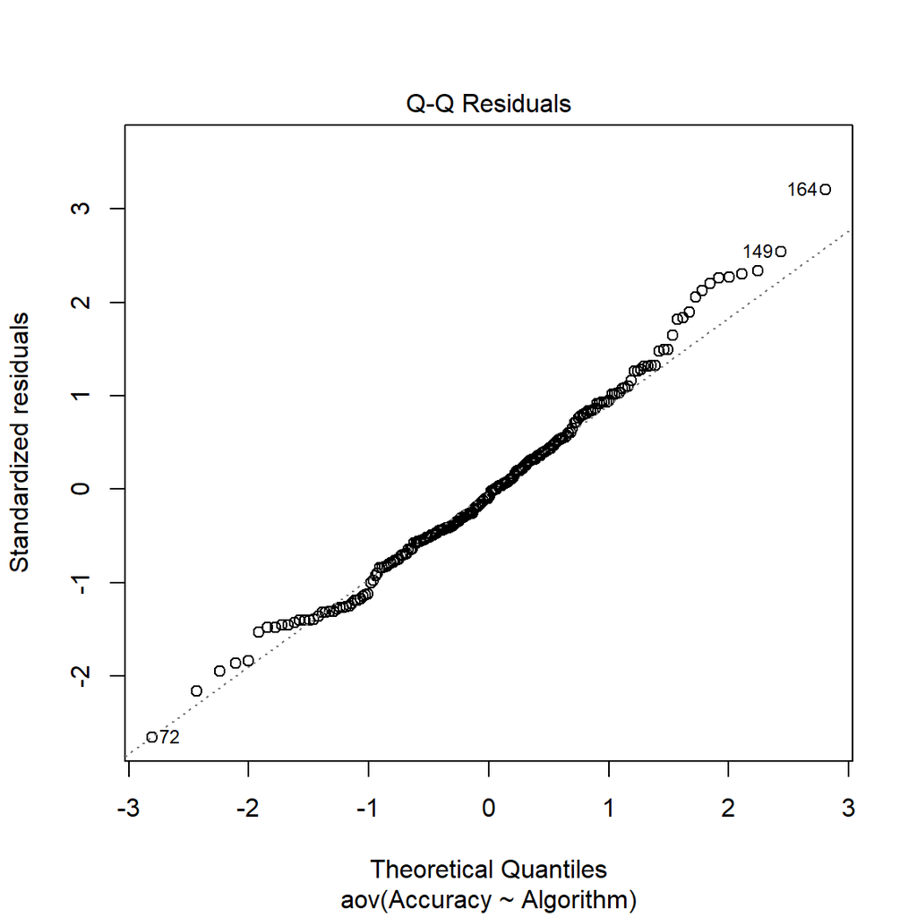

```r
plot(one_way_anova_result, which = 2)
```

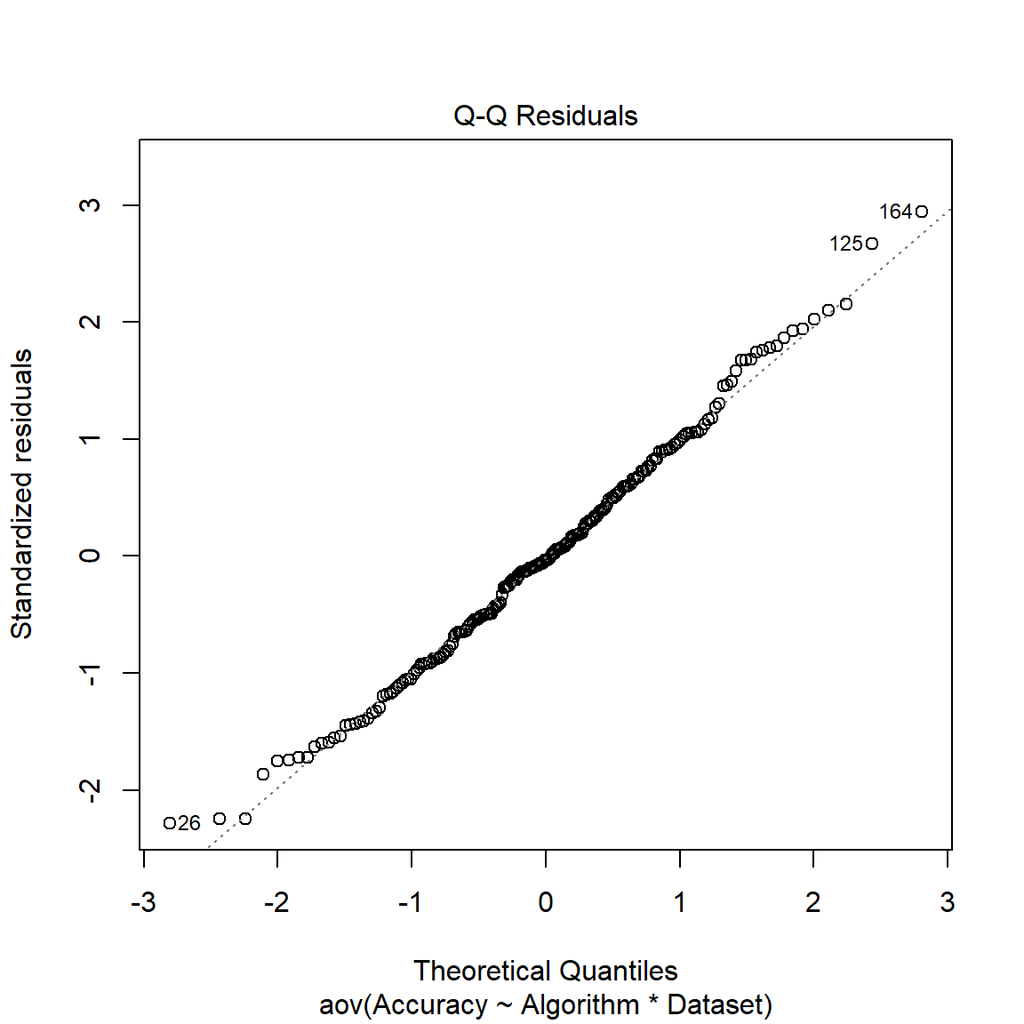

```r
plot(two_way_anova_result, which = 2)
```

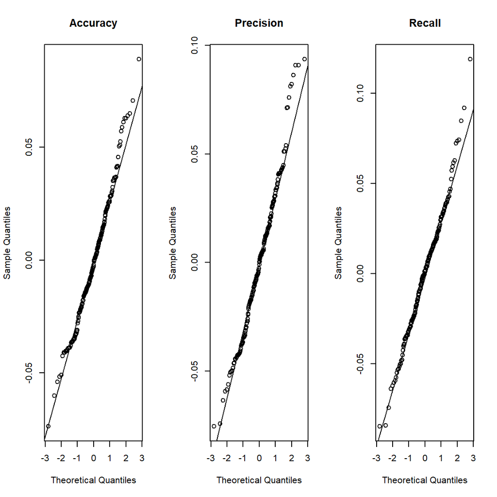

```r
resid_matrix <- residuals(manova_result)
par(mfrow = c(1, ncol(resid_matrix)))
for (i in 1:ncol(resid_matrix)) {
  qqnorm(resid_matrix[, i], main = colnames(resid_matrix)[i])
  qqline(resid_matrix[, i])
}
```

```r
par(mfrow = c(1, 1))
```

**Interpretation:** The Shapiro-Wilk statistic for one-way ANOVA (W = 0.98827, p = 0.09886) and two-way ANOVA (W = 0.99391, p = 0.587) both yield p-values greater than 0.05, so there is no evidence to reject the null hypothesis of normality for either model; the assumption of normally distributed residuals is reasonably supported in both cases.

For MANOVA, residuals were instead evaluated using Mardia’s multivariate normality test, since MANOVA’s normality assumption concerns the joint distribution of residuals across all response variables rather than each variable individually. Mardia’s skewness statistic (10.708, p = 0.381) and kurtosis statistic (0.277, p = 0.782) both yield p-values well above 0.05, so there is no evidence to reject the null hypothesis of multivariate normality. The assumption of normally distributed residuals is therefore reasonably supported for the MANOVA model as well.

`shapiro.test()` evaluates only a single variable’s residuals at a time, while MANOVA’s normality assumption is inherently multivariate. The Mardia test, which properly accounts for the joint distribution, is the appropriate diagnostic here and indicates that the assumption holds.

## 5.4 **Test of Homoscedasticity (Homogeneity of Variance)**

Homoscedasticity (homogeneity of variance) means that the variability of the dependent variable is approximately the same across all groups of the independent variable.

**Levene’s Test** is used in cases where the dependent variable is numeric and the independent variable is categorical.

It tests the following hypothesis:

> H₀: The variance of the dependent variable is equal across all levels of the independent variable.  
> H₁: At least one level of the independent variable has a different variance.

If the p-value is greater than 0.05, we fail to reject the null hypothesis and conclude that there is insufficient evidence to suggest that the group variances differ.

The purpose of checking variances is not only to satisfy a statistical assumption. Variance can provide important practical insights about the consistency or stability of different groups.

A group with a high variance may indicate greater uncertainty, inconsistency, instability, or risk compared with other groups. The interpretation depends on the application domain.

```r
car::leveneTest(Accuracy ~ Algorithm, data = ml_performance_data)
```

|  | Df | F value | Pr(>F) |
| --- | --- | --- | --- |
| group | 3 | 0.2559382 | 0.8570416 |
|  | 196 | NA | NA |

Meaning of the degrees of freedom from the one-way anova:

- `3` = between-group degrees of freedom, suggesting there are 4 algorithms (`k − 1 = 3`)
- `196` = within-group (error) degrees of freedom

This implies a total sample size of approximately:

- `N = 196 + 4 = 200`

assuming no missing values.

```r
car::leveneTest(Accuracy ~ Algorithm * Dataset, data = ml_performance_data)
```

|  | Df | F value | Pr(>F) |
| --- | --- | --- | --- |
| group | 39 | 0.9075325 | 0.6285099 |
|  | 160 | NA | NA |

MANOVA has multiple response variables, and the assumption it actually requires is homogeneity of the *variance-covariance matrices* across groups, not homogeneity of variance for each outcome individually.

````markdown
```{r test_of_homoscedasticity_manova}
heplots::boxM(cbind(Accuracy, Precision, Recall) ~ Algorithm,
              data = ml_performance_data)
```
````

```
#>
#>  Box's M-test for Homogeneity of Covariance Matrices
#>
#> data:  ml_performance_data
#> Chi-Sq (approx.) = 12.3601, df = 18, p-value = 0.8281
```

**Interpretation:**

For the one-way ANOVA, Levene’s test indicated that the variances of accuracy scores were not significantly different across the algorithms, *F*(3, 196) = 0.256, p = .857. The assumption of homogeneity of variance was therefore satisfied.

For the two-way ANOVA, Levene’s test was conducted across all combinations of Algorithm and Dataset to assess homogeneity of variance within each cell of the design. The result was non-significant, *F*(39, 160) = 0.908, p = .629, indicating that the assumption of homogeneity of variance was satisfied across the crossed design.

For the MANOVA, homogeneity of variance-covariance matrices across Algorithm groups was assessed using Box’s M test, since MANOVA’s assumption concerns the joint covariance structure across all dependent variables (Accuracy, Precision, Recall) rather than the variance of each outcome individually. The result was non-significant, $\chi2$ (18) = 12.360, p = .828, indicating no evidence against the assumption of homogeneous covariance matrices across groups. The assumption was therefore reasonably supported.

Box’s M test is known to be highly sensitive to departures from multivariate normality and tends to reject the null more readily as sample size increases; a non-significant result here is reassuring, but a significant result would not necessarily indicate a fatal violation, particularly with reasonably balanced group sizes, given MANOVA’s general robustness to this assumption under such conditions.

## 5.5 **Quantitative Validation of Assumptions — Not Applicable**

Although `aov()` objects do generate residuals and can technically be passed to `gvlma()`, the function’s link function (linearity) component is not meaningful here, since the indepenent variable is a categorical factor with no inherent order or numeric scale. Quantitative validation is instead carried out using assumption-specific tests: `shapiro.test()` for normality, `leveneTest()` for homogeneity of variance, and, where observations are sequentially ordered, `dwtest()` for independence.

# 6 Interpretation of the Results

The presentation of the results and its subsequent interpretation is based on the following notes.

**t-Statistic—t(d.f.):** In a one-sample t-test, the t-statistic measures how far the sample mean is from the hypothesised population mean.

- A t-value close to 0 indicates that the sample mean is very close to the hypothesised value.
- A larger absolute t-value indicates that the observed mean is many standard errors away from the hypothesised mean, providing stronger evidence against the null hypothesis.

The t-statistic has an associated p-value, which quantifies how likely it is to observe a t-value this extreme (or more extreme) if the null hypothesis were true.

**Degrees of Freedom—(d.f.):** Degrees of freedom refers to the number of values in a calculation that are free to vary. It is essentially a measure of how much independent information is available for estimating a statistical parameter.

For example: Imagine you need to calculate the average height of 5 people, and you know the sum of all their heights is 340 inches. If you know the heights of 4 of these people (65, 70, 68, and 72 inches), you can automatically determine the height of the fifth person without measuring them: 340 - (65 + 70 + 68 + 72) = 65 inches In this example, even though there are 5 people, you only have 4 degrees of freedom because once you know 4 heights and the total, the 5th height is no longer “free to vary” – it is determined by the other values.

**Confidence Interval**

A 95% confidence interval (CI) for a parameter provides a range that, under repeated sampling, would contain the true (but unknown) population parameter 95% of the time. Analogy: Imagine shooting arrows at a target. If you drew a circle around where 95% of your arrows landed, that circle is like a confidence interval—it captures the region in which your “shots” (i.e., estimates from different samples) tend to fall.

**Uncertainty quantification:** A CI communicates your estimate’s precision—narrower intervals imply more precise estimates (often due to larger samples or less variability), whereas wider intervals indicate greater uncertainty about the true value.

**Academic Reporting (based on the APA 7th Edition Style)**

Below are some key considerations to note when reporting statistical analysis using the APA style:

1. The type of statistical test must be stated.
2. Although not mandatory, the dependent variable is usually stated first followed by the independent variable when describing relationships, e.g., “…to examine whether advertising expenditures on YouTube, TikTok, and Facebook collectively predict Sales” such that Sales is the dependent variable that depends on advertising expenditures on YouTube, TikTok, and Facebook.
3. Test statistic and parameters: Report the appropriate test statistic (*t*-Statistic, *F*-Statistic, $\chi^2$ , etc.) with the degrees of freedom in parentheses. The italicized statistical symbol is immediately followed by the degrees of freedom in parentheses without a space, e.g., *t*(498) and not t (498).
4. Exact p-values: Report exact p-values, when possible (e.g., *p* = .032), unless they are less than .001, then report as *p* < .001.
5. Effect sizes: Include appropriate effect size measures (e.g., R²) to indicate practical significance.
6. Standard errors: Report standard errors of estimates when relevant. The standard error tells you how much your estimate might vary if you were to repeat your study with different random samples from the same population. A smaller standard error indicates a more precise estimate.
7. Confidence Intervals (CI): The confidence level should be clearly stated whenever you report point estimates (e.g., means, regression coefficients, correlations, etc.). The 95% confidence interval is the most common, and if another level is used (e.g., 90% CI, 99% CI), it should be explicitly mentioned. Confidence intervals are typically enclosed in square brackets [], with the lower and upper limits separated by a comma. For example: 95% CI [-.03, .04]. They are usually reported directly after the statistic they describe, often within the same sentence or in parentheses.
8. Two decimal places: Report to two decimal places, except p-values which may need three or more decimal places. Round to the nearest value; do not truncate.
9. Descriptive statistics: Report relevant means, standard deviations, and sample sizes, e.g., The sample size included 500 observations (M = 25.43, SD = 4.62).
10. Italicize statistical symbols: Use italics for statistical symbols (*t*, *F*, *p*, etc.) but not for Greek letters ( $\mu$, $\sigma$, $\alpha$), subscripts, or parenthetical information, e.g., R² = .45, *F*(2, 97) = 15.62, *p* < .001, The participants (*N* = 120) had an average score (*M* = 25.43, *SD* = 4.62) on the cognitive test.

Further reading: https://apastyle.apa.org/jars

## 6.1 One-Way Analysis of Variance

### 6.1.1 Technical Academic Report (Based on APA Guidelines of Reporting Results)

*An omnibus test is a statistical test that evaluates whether there is a significant effect or difference somewhere among three or more groups or variables, without identifying which specific groups or pairs are driving that effect. The term “omnibus” (Latin for “for all”) reflects that the test addresses a single overall question across the entire set of groups simultaneously, rather than each pairwise comparison individually.*

Prior to interpreting the omnibus test, assumptions were checked. Levene’s test indicated no violation of homogeneity of variance, *F*(3, 196) = 0.26, *p* = .857. The Shapiro-Wilk test indicated that residuals did not significantly depart from normality, *W* = .99, *p* = .099, though this value approaches the conventional threshold and warrants visual confirmation given the sample size. See the figure below for the Q-Q plot that provides a visual confirmation.

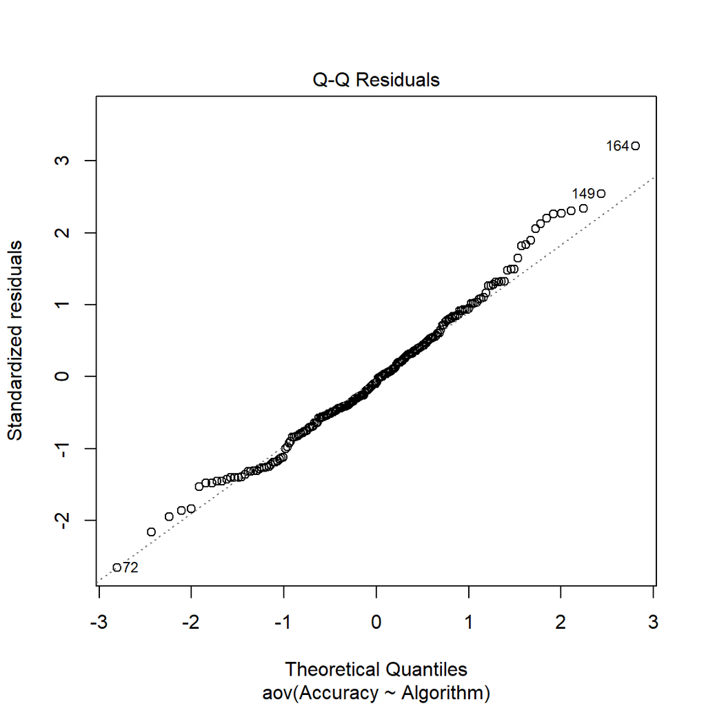

A Durbin-Watson test found no evidence of positive autocorrelation in the residuals, *DW* = 2.16, *p* = .829; this result is meaningful only insofar as the row order of the dataset reflects a genuine sequence.

Post hoc comparisons using Tukey’s HSD test were conducted to examine all pairwise differences. Every comparison was statistically significant, producing a complete and unambiguous ranking: Gradient Boosting > Random Forest > Support Vector Machine > Logistic Regression.

| Comparison | Mean Diff. | 95% CI | *p* (adj.) | Cohen’s *d*¹ |
| --- | --- | --- | --- | --- |
| Gradient Boosting vs. Logistic Regression | 0.090 | [0.075, 0.105] | < .001 | 3.20 |
| Gradient Boosting vs. SVM | 0.069 | [0.054, 0.083] | < .001 | 2.44 |
| Gradient Boosting vs. Random Forest | 0.027 | [0.012, 0.041] | < .001 | 0.95 |
| Random Forest vs. Logistic Regression | 0.063 | [0.049, 0.078] | < .001 | 2.25 |
| Random Forest vs. SVM | 0.042 | [0.027, 0.057] | < .001 | 1.49 |
| SVM vs. Logistic Regression | 0.021 | [0.007, 0.036] | .001 | 0.76 |

¹*d* computed as mean difference divided by the pooled residual SD (√MSE = .0281); not part of the original output, included for effect-size reporting.

### 6.1.2 Non-Technical Business Report

Four predictive algorithms were tested head-to-head on the same accuracy benchmark. The result is unambiguous: Gradient Boosting is the top performer, Random Forest is a clear second, Support Vector Machine is third, and Logistic Regression trails all three. The gap between the best and worst performer is approximately nine percentage points of accuracy, and statistical testing confirms this gap is real, not a product of random variation in the sample. All underlying data-quality checks passed, so the result can be relied upon as stated. The open question is not whether Gradient Boosting wins on accuracy — it does, decisively — but whether accuracy alone is the right basis for a deployment decision, given that cost, speed, and interpretability were not part of this comparison.

### 6.1.3 **Recommendations**

1. **Shortlist Gradient Boosting** as the lead candidate for further development, on the strength of a statistically validated and practically meaningful accuracy advantage over all alternatives.
2. **Do not finalize the deployment decision on accuracy alone.** Gather comparative data on training cost, inference latency, and interpretability before committing, since these factors were outside the scope of this analysis and may offset the accuracy gain depending on the application.
3. **Confirm comparison fairness retrospectively**: verify that all four algorithms received equivalent tuning effort and identical data splits. An accuracy advantage attributable to unequal tuning budgets would not be a genuine algorithm effect.
4. **Replicate on a held-out or temporally distinct dataset** before treating this ranking as generalizable, since a single benchmark run cannot rule out dataset-specific idiosyncrasy.
5. **Document the data-generating process** behind the 200 accuracy observations (e.g., repeated k-fold cross-validation, repeated random splits) — this directly affects whether the independence assumption underlying the reported *p*-values holds.

## 6.2 Two-Way Analysis of Variance

### 6.2.1 Technical Academic Report (Based on APA Guidelines of Reporting Results)

A two-way analysis of variance was conducted to examine the effects of Algorithm (Logistic Regression, Random Forest, Support Vector Machine, Gradient Boosting), Dataset (10 distinct datasets), and their interaction on classification accuracy.

Assumption checks supported the validity of the model. Levene’s test indicated homogeneity of variance across all 40 algorithm-by-dataset cells, *F*(39, 160) = 0.91, *p* = .629. The Shapiro-Wilk test indicated that residuals did not depart from normality, *W* = 0.99, *p* = .587. A Durbin-Watson test found no evidence of positive autocorrelation, *DW* = 2.11, *p* = .786.

| Source | *df* | *SS* | *MS* | *F* | *p* | η² |
| --- | --- | --- | --- | --- | --- | --- |
| Algorithm | 3 | 0.25 | 0.08 | 99.18 | < .001 | .62 |
| Dataset | 9 | 0.01 | 0.00 | 0.81 | .612 | .02 |
| Algorithm × Dataset | 27 | 0.02 | 0.00 | 0.68 | .881 | .04 |
| Residuals | 160 | 0.133 | 0.00 | — | — | .33 |

The main effect of Algorithm was statistically significant and large, *F*(3, 160) = 99.18, *p* < .001, η² = .616. The main effect of Dataset was not significant, *F*(9, 160) = 0.81, *p* = .612, η² = .02, indicating that accuracy did not differ systematically across the ten datasets when averaged over algorithm. The Algorithm × Dataset interaction was not significant, *F*(27, 160) = 0.68, *p* = .881, η² = .04, indicating that the relative ordering of the four algorithms did not vary meaningfully from one dataset to another.

**Post hoc comparisons: Algorithm.** Tukey’s HSD confirmed that all six pairwise algorithm differences were statistically significant, reproducing the strict ordering Gradient Boosting > Random Forest > Support Vector Machine > Logistic Regression.

| Comparison | Diff. | 95% CI | *p* (adj.) | *d*¹ |
| --- | --- | --- | --- | --- |
| Gradient Boosting – Logistic Regression | 0.09 | [0.08, 0.11] | < .001 | 3.12 |
| Gradient Boosting – SVM | 0.07 | [0.05, 0.08] | < .001 | 2.38 |
| Gradient Boosting – Random Forest | 0.03 | [0.01, 0.04] | < .001 | 0.93 |
| Random Forest – Logistic Regression | 0.06 | [0.05, 0.08] | < .001 | 2.20 |
| Random Forest – SVM | 0.04 | [0.03, 0.06] | < .001 | 1.46 |
| SVM – Logistic Regression | 0.02 | [0.01, 0.04] | .002 | 0.74 |

¹*d* = mean difference / √MSE (√0.00083 = 0.0288); included for effect-size context, not part of original output.

**Post hoc comparisons: Dataset.** Consistent with the non-significant main effect, none of the 45 pairwise dataset comparisons reached significance (*p* adj. range = .838–1.000).

**Post hoc comparisons: Algorithm × Dataset.** Given the non-significant omnibus interaction, the 780 individual cell-level contrasts are not interpreted or reported in full. A number of these contrasts nonetheless show small adjusted *p*-values (e.g., Gradient Boosting:Dataset_1 vs. Logistic Regression:Dataset_2, *p* = .0002); this pattern reflects the large main effect of Algorithm surfacing within individual cell pairs, not a true interaction, and should not be read as evidence that algorithm performance depends on dataset. Standard practice is to withhold interpretation of simple effects when the omnibus interaction test is non-significant, and that practice is followed here.

### 6.2.3 Recommendations

1. **Proceed with Gradient Boosting as the lead candidate** with higher confidence than before — the result is now supported by consistency across ten datasets, not a single benchmark run.
2. **Establish precisely what the ten “datasets” represent** before treating this as evidence of cross-domain generalization. This single clarification materially changes how strong a claim can be made.
3. **Still price in cost, latency, and interpretability** before finalizing deployment, as these remain untested dimensions.
4. **Do not interpret the individual Algorithm × Dataset cell comparisons** in any downstream reporting; only the omnibus interaction test (non-significant) is the supportable claim.
5. **Validate on at least one genuinely held-out dataset** collected independently of the original ten, to confirm the result is not an artifact of how those ten datasets were originally selected or constructed.

## 6.3 Multiple Analysis of Variance

### 6.3.1 Technical Academic Report (Based on APA Guidelines of Reporting Results)

A one-way multivariate analysis of variance (MANOVA) was conducted to examine the effect of Algorithm (Logistic Regression, Random Forest, Support Vector Machine, Gradient Boosting) on a combined outcome of classification Accuracy, Precision, and Recall.

**Assumption checks.** Mardia’s test indicated no significant departure from multivariate normality in skewness, *b* = 10.71, *p* = .381, or kurtosis, *b* = 0.28, *p* = .782. Box’s M test indicated no significant violation of the homogeneity of covariance matrices assumption, χ²(18) = 12.36, *p* = .828. A Durbin-Watson test found no evidence of positive autocorrelation, *DW* = 2.16, *p* = .815.

**Multivariate effect.** The multivariate effect of Algorithm on the combined outcome was statistically significant, Pillai’s Trace = 0.67, *F*(9, 588) = 18.60, *p* < .001.

**Univariate follow-up tests.** Given the significant multivariate effect, univariate ANOVAs were examined for each outcome as protected follow-up tests.

| Outcome | *df* | *MS* | *F* | *p* | η² |
| --- | --- | --- | --- | --- | --- |
| Accuracy | 3, 196 | 0.0823 | 104.75 | < .001 | .616 |
| Precision | 3, 196 | 0.0833 | 74.55 | < .001 | .533 |
| Recall | 3, 196 | 0.0838 | 77.71 | < .001 | .543 |

All three effects were significant and large, with Algorithm explaining between 53% and 62% of variance depending on outcome.

**Post hoc comparisons.** Tukey’s HSD was conducted separately for each outcome.

*Accuracy*

| Comparison | Diff. | 95% CI | *p* (adj.) | *d*¹ |
| --- | --- | --- | --- | --- |
| Gradient Boosting – Logistic Regression | 0.09 | [0.08, 0.11] | < .001 | 3.21 |
| Gradient Boosting – SVM | 0.07 | [0.05, 0.08] | < .001 | 2.45 |
| Gradient Boosting – Random Forest | 0.03 | [0.01, 0.04] | < .001 | 0.95 |
| Random Forest – Logistic Regression | 0.06 | [0.05, 0.08] | < .001 | 2.26 |
| Random Forest – SVM | 0.04 | [0.03, 0.06] | < .001 | 1.50 |
| SVM – Logistic Regression | 0.02 | [0.01, 0.04] | .001 | 0.76 |

*Precision*

| Comparison | Diff. | 95% CI | *p* (adj.) | *d*¹ |
| --- | --- | --- | --- | --- |
| Gradient Boosting – Logistic Regression | 0.09 | [0.07, 0.11] | < .001 | 2.64 |
| Gradient Boosting – SVM | 0.07 | [0.05, 0.08] | < .001 | 2.00 |
| Gradient Boosting – Random Forest | 0.02 | [0.00, 0.04] | .018 | 0.59 |
| Random Forest – Logistic Regression | 0.07 | [0.05, 0.09] | < .001 | 2.05 |
| Random Forest – SVM | 0.05 | [0.03, 0.06] | < .001 | 1.40 |
| SVM – Logistic Regression | 0.02 | [0.00, 0.04] | .008 | 0.65 |

*Recall*

| Comparison | Diff. | 95% CI | *p* (adj.) | *d*¹ |
| --- | --- | --- | --- | --- |
| Gradient Boosting – Logistic Regression | 0.09 | [0.07, 0.11] | < .001 | 2.69 |
| Gradient Boosting – SVM | 0.07 | [0.05, 0.08] | < .001 | 1.99 |
| Gradient Boosting – Random Forest | 0.02 | [0.00, 0.04] | .030 | 0.56 |
| Random Forest – Logistic Regression | 0.07 | [0.05, 0.09] | < .001 | 2.14 |
| Random Forest – SVM | 0.05 | [0.03, 0.06] | < .001 | 1.43 |
| SVM – Logistic Regression | 0.02 | [0.01, 0.04] | .003 | 0.71 |

¹*d* = mean difference / √MSE; not part of the original output, included for effect-size context.

### 6.3.3 Recommendations

1. **Proceed with Gradient Boosting as the recommended algorithm.** The conclusion is now supported by full convergence across three independent performance metrics, the strongest evidentiary standard reached in this evaluation.
2. **Treat the Gradient Boosting vs. Random Forest margin as the genuine decision point**, not the broader ranking. If training cost, inference latency, or interpretability favor Random Forest, this is the one comparison where that trade-off is close enough to matter.
3. **Apply a stricter correction across the three outcome families** (e.g., Bonferroni at α = .0167 instead of .05) specifically to the Gradient Boosting–Random Forest contrasts before treating them as fully secure, since Tukey’s correction here only protects within each individual metric’s six comparisons, not across all eighteen.
4. **Report all three Tukey tables together**, as done above, rather than any one in isolation — the convergence across metrics is itself part of the evidentiary strength and should not be dropped in summarized reporting.
5. **If forced to choose between Gradient Boosting and Random Forest under resource constraints**, treat it as a genuine cost-benefit decision rather than a statistical formality, given how narrow and comparatively fragile that specific margin is.

# 7 References and Further Reading

American Psychological Association. (2025, February). *Journal Article Reporting Standards (JARS)*. APA Style. Retrieved April 28, 2025, from https://apastyle.apa.org/jars

Hodeghatta, U. R., & Nayak, U. (2023). *Practical Business Analytics Using R and Python: Solve Business Problems Using a Data-driven Approach* (2nd ed.). Apress. https://link.springer.com/book/10.1007/978-1-4842-8754-5